# White-Britt-ADA-homework-extra

BA White

8/30/2020

#### ADA Additional assignment

Add necessary packages

```r
library(tidyverse)
library(lme4)
library(AICcmodavg)
```

#### CHALLENGE 1

Read the datafiles “gini-index-data.csv” and “world-bank.csv” into two data frames, **gini** and **worldbank**.

```r
#Read in datafiles
gini <- read_csv("gini-index-data.csv")
worldbank <- read_csv("world-bank-data.csv")
```

For the gini data frame, pivot it from wide to long format so that you have a single row with a GINI index values for each combination of Country Name and Year. HINT: Use {tidyr}’s pivot_longer()function!

```r
head(gini)
```

```
## # A tibble: 6 x 64
##   `Country Name` `Country Code` `Indicator Name` `Indicator Code` `1960` `1961`
##   <chr>          <chr>          <chr>            <chr>            <lgl>  <lgl>
## 1 Aruba          ABW            GINI index (Wor~ SI.POV.GINI      NA     NA
## 2 Afghanistan    AFG            GINI index (Wor~ SI.POV.GINI      NA     NA
## 3 Angola         AGO            GINI index (Wor~ SI.POV.GINI      NA     NA
## 4 Albania        ALB            GINI index (Wor~ SI.POV.GINI      NA     NA
## 5 Andorra        AND            GINI index (Wor~ SI.POV.GINI      NA     NA
## 6 Arab World     ARB            GINI index (Wor~ SI.POV.GINI      NA     NA
## # ... with 58 more variables: `1962` <lgl>, `1963` <lgl>, `1964` <lgl>,
## #   `1965` <lgl>, `1966` <lgl>, `1967` <dbl>, `1968` <lgl>, `1969` <dbl>,
## #   `1970` <lgl>, `1971` <dbl>, `1972` <lgl>, `1973` <lgl>, `1974` <dbl>,
## #   `1975` <dbl>, `1976` <lgl>, `1977` <lgl>, `1978` <dbl>, `1979` <dbl>,
## #   `1980` <dbl>, `1981` <dbl>, `1982` <dbl>, `1983` <dbl>, `1984` <dbl>,
## #   `1985` <dbl>, `1986` <dbl>, `1987` <dbl>, `1988` <dbl>, `1989` <dbl>,
## #   `1990` <dbl>, `1991` <dbl>, `1992` <dbl>, `1993` <dbl>, `1994` <dbl>,
## #   `1995` <dbl>, `1996` <dbl>, `1997` <dbl>, `1998` <dbl>, `1999` <dbl>,
## #   `2000` <dbl>, `2001` <dbl>, `2002` <dbl>, `2003` <dbl>, `2004` <dbl>,
## #   `2005` <dbl>, `2006` <dbl>, `2007` <dbl>, `2008` <dbl>, `2009` <dbl>,
## #   `2010` <dbl>, `2011` <dbl>, `2012` <dbl>, `2013` <dbl>, `2014` <dbl>,
## #   `2015` <dbl>, `2016` <dbl>, `2017` <dbl>, `2018` <dbl>, `2019` <lgl>
```

```r
#Now we will pivot the gini data
ginilonger <- gini %>%
  pivot_longer(cols = 5:64)
```

Print the first 10 lines of each dataset.

```r
#Now Print
print(ginilonger)
```

```
## # A tibble: 15,840 x 6
##    `Country Name` `Country Code` `Indicator Name`   `Indicator Code` name  value
##    <chr>          <chr>          <chr>              <chr>            <chr> <dbl>
##  1 Aruba          ABW            GINI index (World~ SI.POV.GINI      1960     NA
##  2 Aruba          ABW            GINI index (World~ SI.POV.GINI      1961     NA
##  3 Aruba          ABW            GINI index (World~ SI.POV.GINI      1962     NA
##  4 Aruba          ABW            GINI index (World~ SI.POV.GINI      1963     NA
##  5 Aruba          ABW            GINI index (World~ SI.POV.GINI      1964     NA
##  6 Aruba          ABW            GINI index (World~ SI.POV.GINI      1965     NA
##  7 Aruba          ABW            GINI index (World~ SI.POV.GINI      1966     NA
##  8 Aruba          ABW            GINI index (World~ SI.POV.GINI      1967     NA
##  9 Aruba          ABW            GINI index (World~ SI.POV.GINI      1968     NA
## 10 Aruba          ABW            GINI index (World~ SI.POV.GINI      1969     NA
## # ... with 15,830 more rows
```

```r
print(worldbank)
```

```
## # A tibble: 217 x 11
##    iso3c country region income population land_area_skm pop_density
##    <chr> <chr>   <chr>  <chr>       <dbl>         <dbl>       <dbl>
##  1 ABW   Aruba   Latin~ High ~     106314           180       588.
##  2 AFG   Afghan~ South~ Low i~   38041754        652860        56.9
##  3 AGO   Angola  Sub-S~ Lower~   31825295       1246700        24.7
##  4 ALB   Albania Europ~ Upper~    2854191         27400       105.
##  5 AND   Andorra Europ~ High ~      77142           470       164.
##  6 ARE   United~ Middl~ High ~    9770529         71020       136.
##  7 ARG   Argent~ Latin~ Upper~   44938712       2736690        16.3
##  8 ARM   Armenia Europ~ Upper~    2957731         28470       104.
##  9 ASM   Americ~ East ~ Upper~      55312           200       277.
## 10 ATG   Antigu~ Latin~ High ~      97118           440       219.
## # ... with 207 more rows, and 4 more variables: pop_largest_city <dbl>,
## #   life_expectancy <dbl>, gdp_capita <dbl>, timestamp <dttm>
```

#### CHALLENGE 2

Join the GINI index and World Bank data sets together using the “Country Code” in gini and “iso3c” code in worldbank into a new data frame, d. HINT: Use {dplyr}’s left_join() function to add data from worldbank to every row in gini.

```r
#Join datasets
newdf <- left_join(ginilonger, worldbank, by = c("Country Code" = "iso3c"))
glimpse(newdf)
```

```
## Rows: 15,840
## Columns: 16
## $ `Country Name`   <chr> "Aruba", "Aruba", "Aruba", "Aruba", "Aruba", "Arub...
## $ `Country Code`   <chr> "ABW", "ABW", "ABW", "ABW", "ABW", "ABW", "ABW", "...
## $ `Indicator Name` <chr> "GINI index (World Bank estimate)", "GINI index (W...
## $ `Indicator Code` <chr> "SI.POV.GINI", "SI.POV.GINI", "SI.POV.GINI", "SI.P...
## $ name             <chr> "1960", "1961", "1962", "1963", "1964", "1965", "1...
## $ value            <dbl> NA, NA, NA, NA, NA, NA, NA, NA, NA, NA, NA, NA, NA...
## $ country          <chr> "Aruba", "Aruba", "Aruba", "Aruba", "Aruba", "Arub...
## $ region           <chr> "Latin America & Caribbean", "Latin America & Cari...
## $ income           <chr> "High income", "High income", "High income", "High...
## $ population       <dbl> 106314, 106314, 106314, 106314, 106314, 106314, 10...
## $ land_area_skm    <dbl> 180, 180, 180, 180, 180, 180, 180, 180, 180, 180, ...
## $ pop_density      <dbl> 588.0278, 588.0278, 588.0278, 588.0278, 588.0278, ...
## $ pop_largest_city <dbl> NA, NA, NA, NA, NA, NA, NA, NA, NA, NA, NA, NA, NA...
## $ life_expectancy  <dbl> 76.152, 76.152, 76.152, 76.152, 76.152, 76.152, 76...
## $ gdp_capita       <dbl> 26630.21, 26630.21, 26630.21, 26630.21, 26630.21, ...
## $ timestamp        <dttm> 2020-08-24 12:43:22, 2020-08-24 12:43:22, 2020-08...
```

Convert the variable “Year” to be an integer.

```r
#Convert "Year" ie "name" to integer
newdf$name = as.integer(as.character(newdf$name))
newdf$'Country Name' = as.factor(as.character(newdf$'Country Name'))
glimpse(newdf)
```

```
## Rows: 15,840
## Columns: 16
## $ `Country Name`   <fct> Aruba, Aruba, Aruba, Aruba, Aruba, Aruba, Aruba, A...
## $ `Country Code`   <chr> "ABW", "ABW", "ABW", "ABW", "ABW", "ABW", "ABW", "...
## $ `Indicator Name` <chr> "GINI index (World Bank estimate)", "GINI index (W...
## $ `Indicator Code` <chr> "SI.POV.GINI", "SI.POV.GINI", "SI.POV.GINI", "SI.P...
## $ name             <int> 1960, 1961, 1962, 1963, 1964, 1965, 1966, 1967, 19...
## $ value            <dbl> NA, NA, NA, NA, NA, NA, NA, NA, NA, NA, NA, NA, NA...
## $ country          <chr> "Aruba", "Aruba", "Aruba", "Aruba", "Aruba", "Arub...
## $ region           <chr> "Latin America & Caribbean", "Latin America & Cari...
## $ income           <chr> "High income", "High income", "High income", "High...
## $ population       <dbl> 106314, 106314, 106314, 106314, 106314, 106314, 10...
## $ land_area_skm    <dbl> 180, 180, 180, 180, 180, 180, 180, 180, 180, 180, ...
## $ pop_density      <dbl> 588.0278, 588.0278, 588.0278, 588.0278, 588.0278, ...
## $ pop_largest_city <dbl> NA, NA, NA, NA, NA, NA, NA, NA, NA, NA, NA, NA, NA...
## $ life_expectancy  <dbl> 76.152, 76.152, 76.152, 76.152, 76.152, 76.152, 76...
## $ gdp_capita       <dbl> 26630.21, 26630.21, 26630.21, 26630.21, 26630.21, ...
## $ timestamp        <dttm> 2020-08-24 12:43:22, 2020-08-24 12:43:22, 2020-08...
```

Convert the variables “Country Name” and “income” to be factors. For “income”, order the levels of the factor from “Low income” to “High income”. HINT: See the factor() function.

```r
#order levels of factor from low to high income
unique(newdf$income)
```

```
## [1] "High income"         "Low income"          "Lower middle income"
## [4] "Upper middle income" NA
```

```r
newdf$income = as.factor(as.character(newdf$income))
newdf$income <- factor(newdf$income, levels = c("Low income", "Lower middle income", "Upper middle income", "High income"))
levels(newdf$income)
```

```
## [1] "Low income"          "Lower middle income" "Upper middle income"
## [4] "High income"
```

```r
glimpse(newdf)
```

```
## Rows: 15,840
## Columns: 16
## $ `Country Name`   <fct> Aruba, Aruba, Aruba, Aruba, Aruba, Aruba, Aruba, A...
## $ `Country Code`   <chr> "ABW", "ABW", "ABW", "ABW", "ABW", "ABW", "ABW", "...
## $ `Indicator Name` <chr> "GINI index (World Bank estimate)", "GINI index (W...
## $ `Indicator Code` <chr> "SI.POV.GINI", "SI.POV.GINI", "SI.POV.GINI", "SI.P...
## $ name             <int> 1960, 1961, 1962, 1963, 1964, 1965, 1966, 1967, 19...
## $ value            <dbl> NA, NA, NA, NA, NA, NA, NA, NA, NA, NA, NA, NA, NA...
## $ country          <chr> "Aruba", "Aruba", "Aruba", "Aruba", "Aruba", "Arub...
## $ region           <chr> "Latin America & Caribbean", "Latin America & Cari...
## $ income           <fct> High income, High income, High income, High income...
## $ population       <dbl> 106314, 106314, 106314, 106314, 106314, 106314, 10...
## $ land_area_skm    <dbl> 180, 180, 180, 180, 180, 180, 180, 180, 180, 180, ...
## $ pop_density      <dbl> 588.0278, 588.0278, 588.0278, 588.0278, 588.0278, ...
## $ pop_largest_city <dbl> NA, NA, NA, NA, NA, NA, NA, NA, NA, NA, NA, NA, NA...
## $ life_expectancy  <dbl> 76.152, 76.152, 76.152, 76.152, 76.152, 76.152, 76...
## $ gdp_capita       <dbl> 26630.21, 26630.21, 26630.21, 26630.21, 26630.21, ...
## $ timestamp        <dttm> 2020-08-24 12:43:22, 2020-08-24 12:43:22, 2020-08...
```

Drop all rows from d that are missing GINI index data (many years for many countries). HINT: Use {dplyr}’s filter() function.

```r
#drop missing GINI Index missing values
d <- newdf %>%
 filter(!is.na(value))
```

How many rows are in the dataset at this point? HINT: It should be over 1000 and under 2000!

```r
#How many rows?
nrow(d)
```

```
## [1] 1678
```

#### CHALLENGE 3

Using {ggplot}, with the data frame, d, as your data argument, plot on the same graph the GINI index across years for the “Group of Seven” (G7) countries, which are the largest IMF-advanced economies in the world (i.e., the United States, United Kingdom, Canada, France, Germany, Italy, and Japan) plus China, Russia, and Iran. HINT: When you assign the data= argument in {ggplot}, you can have the assignment be the result of a piped set of {dplyr} operations. **NOTE** that in d at this point, the names “Russia” and “China” are not used as country names (check out the country codes RUS and IRN). Use {dplyr} and str_replace() to change the original country names to “Russia” and “Iran” before making your plot.

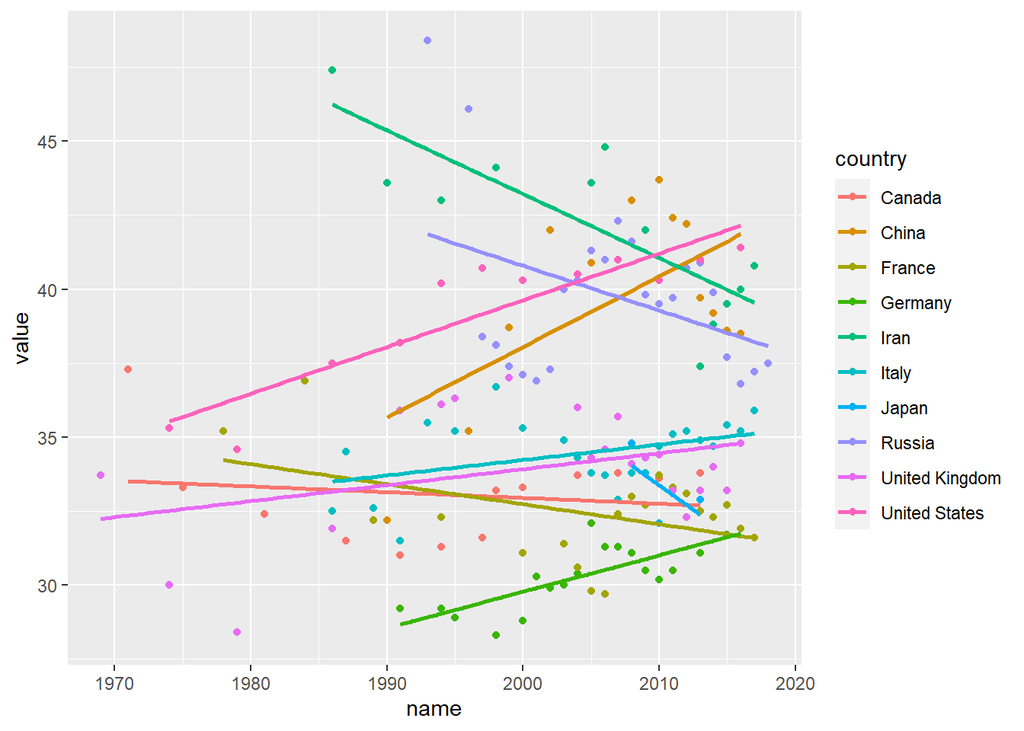

```r
##change the names of Russia and Iran(?)
d$country <- str_replace(d$country,"Iran, Islamic Rep.", "Iran")
d$country <- str_replace(d$country,"Russian Federation", "Russia")

##use ggplot to plot the GINI Index/years for largest IMF advanced economies in the world, ie. the "Group of Seven Countries"
d %>%
filter(country %in% c("United States", "United Kingdom", "Canada", "France", "Germany", "Italy", "Japan", "China", "Russia", "Iran")) %>%
  ggplot(aes(name, value, color = country)) +
  geom_point() +
  geom_smooth(se = FALSE, method = lm)
```

#### CHALLENGE 4

Again using {ggplot}, with d as your dataset, add Brazil, Bolivia, Colombia, India, Vietnam, Rwanda, Uganda, and Ethiopia to the list of countries you examine and make a plot with four panels, where you facet by “income”. NOTE: For both Challenge 4 and Challenge 5, try to generate the plots with a SINGLE line of code, and orient the legend at the bottom and remove the title of the legend. HINT: You will probably want to use theme(legend.position=“bottom”, legend.title = element_blank()).

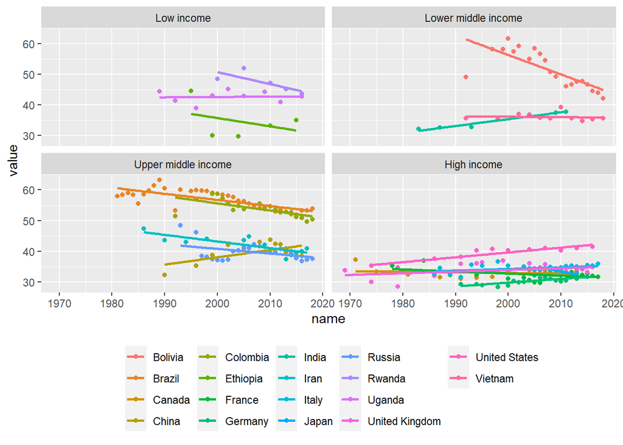

```r
#using ggplot, add Brazil, Bolivia, Colombia, India, Vietnam, Rwanda, Uganda, and Ethiopia
d %>%
filter(country %in% c("Brazil", "Bolivia", "Colombia", "India", "Vietnam", "Rwanda", "Uganda", "Ethiopia", "United States", "United Kingdom", "Canada", "France", "Germany", "Italy", "Japan", "China", "Russia", "Iran")) %>%
  ggplot(aes(name, value, color = country)) +
  geom_point() +
  geom_smooth(se = FALSE, method = lm)+
  theme(legend.position = "bottom", legend.title = element_blank())+
  facet_wrap(~income)
```

#### CHALLENGE 5

Using {dplyr}’s group_by() and summarize() functions, create a new data frame, gini_summary, that includes the minimum, maximum, average, oldest GINI index, latest GINI index, year of the oldest GINI index, and year of the latest GINI index for all countries in d, as well as a variable, “gini_change”, that is the difference in the GINI index between the most recent and the oldest GINI indices for a country divided by the number of years between the most recent and oldest indices (i.e., that summarizes the change in GINI index across time for each country, given the data available). Arrange that table in descending order of the “gini_change” within each “income” group, with the “income” groups ordered from highest to lowest. HINT: This can all be done in single line of code by piping d into group_by(), summarize(), and arrange() functions. Within summarize(), you will be creating multiple new summary variables. Here’s one way that you can create one of these variables, the GINI value for the oldest GINI index in the dataset for a particular group oldest_gini = `GINI Index`[which(`Year` == min(`Year`))]

```r
gini_summary <-
d %>%
rename(gini = value, year = name) %>%
group_by(country, income) %>%
summarize(
    min_GINI = min(gini),
    max_GINI = max(gini),
    mean_GINI = mean(gini),
    oldest_gini = gini[which(year == min(year))],
    latest_gini = gini[which(year == max(year))],
    oldest_year = min(year),
    latest_year = max(year),
    gini_change = (latest_gini-oldest_gini)/(latest_year-oldest_year)
    ) %>%
arrange(desc(income), desc(gini_change))
```

#### CHALLENGE 6

Using {ggplot} and the gini_summary dataset, make a boxplot of “gini_change” by “income” group.

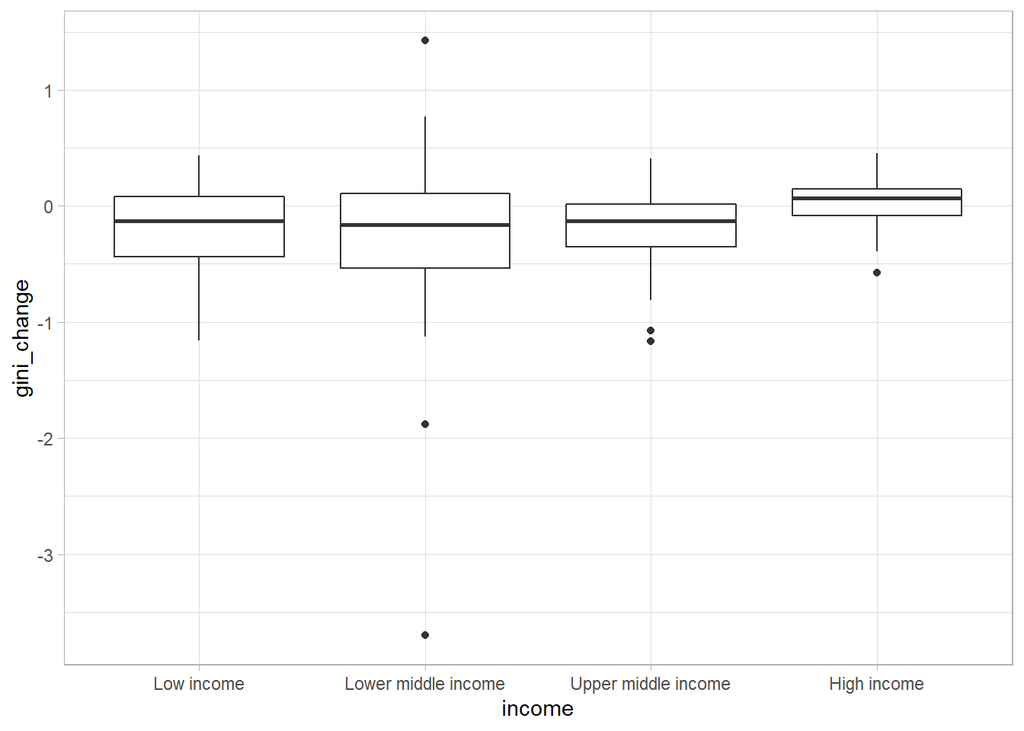

```r
gini_summary %>%
  ggplot(aes(income, gini_change))+
  geom_boxplot()+
  theme_light()
```

#### CHALLENGE 7:

Return to data frame d and filter() it to only include the 18 countries mentioned in Challenges 3 and 4.

```r
#the data we will look at
d18 <-
d %>%
filter(country %in% c("Brazil", "Bolivia", "Colombia", "India", "Vietnam", "Rwanda", "Uganda", "Ethiopia", "United States", "United Kingdom", "Canada", "France", "Germany", "Italy", "Japan", "China", "Russia", "Iran")) %>%
rename(gini = value, year = name) %>%
group_by(country, income, population, gdp_capita, gini) %>%
summarize(
    min_GINI = min(gini),
    max_GINI = max(gini),
    mean_GINI = mean(gini),
    oldest_gini = gini[which(year == min(year))],
    latest_gini = gini[which(year == max(year))],
    oldest_year = min(year),
    latest_year = max(year),
    gini_change = (latest_gini-oldest_gini)/(latest_year-oldest_year)
    )
```

Using linear mixed effect models, explore how the GINI index is related to “population”, “income”, and “gdp_capita” as predictors when “Country Name” is included as a random factor in the model. You should construct a full model that includes all three predictors plus the random factor of “Country Name” as well as a complete set of nested models (no need to include interaction terms). The null model should include only the random factor.

```r
library(lme4)
#models exploring how the GINI index is related to “population”, “income”, and “gdp_capita” as predictors when “Country Name” is included as a random factor in the model. You should construct a full model that includes all three predictors plus the random factor of “Country Name” as well as a complete set of nested models (no need to include interaction terms).

full_model <- lmer(data = d18, gini ~ population + income + gdp_capita + (1 | country), REML = FALSE)
summary(full_model)
```

```
## Linear mixed model fit by maximum likelihood  ['lmerMod']
## Formula: gini ~ population + income + gdp_capita + (1 | country)
##    Data: d18
##
##      AIC      BIC   logLik deviance df.resid
##   1290.2   1318.1   -637.1   1274.2      232
##
## Scaled residuals:
##     Min      1Q  Median      3Q     Max
## -3.0999 -0.5908 -0.0063  0.5294  3.3228
##
## Random effects:
##  Groups   Name        Variance Std.Dev.
##  country  (Intercept) 24.723   4.972
##  Residual              9.124   3.021
## Number of obs: 240, groups:  country, 18
##
## Fixed effects:
##                             Estimate Std. Error t value
## (Intercept)                4.169e+01  2.975e+00  14.016
## population                -6.464e-09  3.187e-09  -2.029
## incomeLower middle income  1.994e+00  4.394e+00   0.454
## incomeUpper middle income  5.198e+00  4.617e+00   1.126
## incomeHigh income         -1.716e+01  1.458e+01  -1.177
## gdp_capita                 2.125e-04  3.082e-04   0.690
##
## Correlation of Fixed Effects:
##             (Intr) popltn incLmi incUmi incmHi
## population  -0.056
## incmLwrmddi -0.644 -0.304
## incmUpprmdi -0.579 -0.191  0.547
## incmHghincm -0.122  0.039  0.224  0.667
## gdp_capita  -0.082 -0.053 -0.086 -0.551 -0.970
## fit warnings:
## Some predictor variables are on very different scales: consider rescaling
```

```r
reducednopop <- lmer(data = d18, gini ~ income + gdp_capita + (1 | country), REML = FALSE)
summary(reducednopop)
```

```
## Linear mixed model fit by maximum likelihood  ['lmerMod']
## Formula: gini ~ income + gdp_capita + (1 | country)
##    Data: d18
##
##      AIC      BIC   logLik deviance df.resid
##   1291.9   1316.3   -639.0   1277.9      233
##
## Scaled residuals:
##     Min      1Q  Median      3Q     Max
## -3.0933 -0.5816 -0.0069  0.5244  3.3291
##
## Random effects:
##  Groups   Name        Variance Std.Dev.
##  country  (Intercept) 30.551   5.527
##  Residual              9.124   3.021
## Number of obs: 240, groups:  country, 18
##
## Fixed effects:
##                             Estimate Std. Error t value
## (Intercept)                4.135e+01  3.283e+00  12.596
## incomeLower middle income -7.326e-01  4.633e+00  -0.158
## incomeUpper middle income  3.402e+00  5.018e+00   0.678
## incomeHigh income         -1.601e+01  1.615e+01  -0.991
## gdp_capita                 1.800e-04  3.412e-04   0.527
##
## Correlation of Fixed Effects:
##             (Intr) incLmi incUmi incmHi
## incmLwrmddi -0.694
## incmUpprmdi -0.601  0.522
## incmHghincm -0.119  0.247  0.688
## gdp_capita  -0.085 -0.107 -0.573 -0.970
## fit warnings:
## Some predictor variables are on very different scales: consider rescaling
```

```r
reducednoincome <- lmer(data = d18, gini ~ population + gdp_capita + (1 | country), REML = FALSE)
summary(reducednoincome)
```

```
## Linear mixed model fit by maximum likelihood  ['lmerMod']
## Formula: gini ~ population + gdp_capita + (1 | country)
##    Data: d18
##
##      AIC      BIC   logLik deviance df.resid
##   1291.2   1308.6   -640.6   1281.2      235
##
## Scaled residuals:
##     Min      1Q  Median      3Q     Max
## -3.1175 -0.6008  0.0017  0.5371  3.3045
##
## Random effects:
##  Groups   Name        Variance Std.Dev.
##  country  (Intercept) 36.903   6.075
##  Residual              9.126   3.021
## Number of obs: 240, groups:  country, 18
##
## Fixed effects:
##               Estimate Std. Error t value
## (Intercept)  4.558e+01  2.386e+00  19.105
## population  -4.417e-09  3.620e-09  -1.220
## gdp_capita  -2.222e-04  7.101e-05  -3.129
##
## Correlation of Fixed Effects:
##            (Intr) popltn
## population -0.497
## gdp_capita -0.711  0.214
## fit warnings:
## Some predictor variables are on very different scales: consider rescaling
```

```r
reducednogdp <- lmer(data = d18, gini ~ population + income + (1 | country), REML = FALSE)
summary(reducednogdp)
```

```
## Linear mixed model fit by maximum likelihood  ['lmerMod']
## Formula: gini ~ population + income + (1 | country)
##    Data: d18
##
##      AIC      BIC   logLik deviance df.resid
##   1288.7   1313.0   -637.3   1274.7      233
##
## Scaled residuals:
##     Min      1Q  Median      3Q     Max
## -3.1003 -0.5924 -0.0100  0.5305  3.3223
##
## Random effects:
##  Groups   Name        Variance Std.Dev.
##  country  (Intercept) 25.385   5.038
##  Residual              9.124   3.021
## Number of obs: 240, groups:  country, 18
##
## Fixed effects:
##                             Estimate Std. Error t value
## (Intercept)                4.186e+01  3.002e+00  13.945
## population                -6.348e-09  3.223e-09  -1.970
## incomeLower middle income  2.253e+00  4.434e+00   0.508
## incomeUpper middle income  6.951e+00  3.902e+00   1.781
## incomeHigh income         -7.404e+00  3.574e+00  -2.072
##
## Correlation of Fixed Effects:
##             (Intr) popltn incLmi incUmi
## population  -0.060
## incmLwrmddi -0.656 -0.310
## incmUpprmdi -0.751 -0.264  0.601
## incmHghincm -0.834 -0.048  0.581  0.656
## fit warnings:
## Some predictor variables are on very different scales: consider rescaling
```

```r
reducedpop <- lmer(data = d18, gini ~ population + (1 | country), REML = FALSE)
summary(reducedpop)
```

```
## Linear mixed model fit by maximum likelihood  ['lmerMod']
## Formula: gini ~ population + (1 | country)
##    Data: d18
##
##      AIC      BIC   logLik deviance df.resid
##   1297.1   1311.0   -644.5   1289.1      236
##
## Scaled residuals:
##     Min      1Q  Median      3Q     Max
## -3.1149 -0.5968  0.0033  0.5272  3.3071
##
## Random effects:
##  Groups   Name        Variance Std.Dev.
##  country  (Intercept) 57.442   7.579
##  Residual              9.126   3.021
## Number of obs: 240, groups:  country, 18
##
## Fixed effects:
##               Estimate Std. Error t value
## (Intercept)  4.026e+01  2.083e+00  19.323
## population  -1.995e-09  4.389e-09  -0.455
##
## Correlation of Fixed Effects:
##            (Intr)
## population -0.502
## fit warnings:
## Some predictor variables are on very different scales: consider rescaling
```

```r
reducedincome <- lmer(data = d18, gini ~ income + (1 | country), REML = FALSE)
summary(reducedincome)
```

```
## Linear mixed model fit by maximum likelihood  ['lmerMod']
## Formula: gini ~ income + (1 | country)
##    Data: d18
##
##      AIC      BIC   logLik deviance df.resid
##   1290.2   1311.1   -639.1   1278.2      234
##
## Scaled residuals:
##     Min      1Q  Median      3Q     Max
## -3.0938 -0.5896 -0.0069  0.5248  3.3286
##
## Random effects:
##  Groups   Name        Variance Std.Dev.
##  country  (Intercept) 31.028   5.570
##  Residual              9.125   3.021
## Number of obs: 240, groups:  country, 18
##
## Fixed effects:
##                           Estimate Std. Error t value
## (Intercept)                41.5016     3.2954  12.594
## incomeLower middle income  -0.4717     4.6403  -0.102
## incomeUpper middle income   4.9178     4.1442   1.187
## incomeHigh income          -7.7391     3.9282  -1.970
##
## Correlation of Fixed Effects:
##             (Intr) incLmi incUmi
## incmLwrmddi -0.710
## incmUpprmdi -0.795  0.565
## incmHghincm -0.839  0.596  0.667
```

```r
reducedgdp <- lmer(data = d18, gini ~ gdp_capita + (1 | country), REML = FALSE)
summary(reducedgdp)
```

```
## Linear mixed model fit by maximum likelihood  ['lmerMod']
## Formula: gini ~ gdp_capita + (1 | country)
##    Data: d18
##
##      AIC      BIC   logLik deviance df.resid
##   1290.7   1304.6   -641.3   1282.7      236
##
## Scaled residuals:
##     Min      1Q  Median      3Q     Max
## -3.1145 -0.5856  0.0117  0.5235  3.3074
##
## Random effects:
##  Groups   Name        Variance Std.Dev.
##  country  (Intercept) 40.007   6.325
##  Residual              9.126   3.021
## Number of obs: 240, groups:  country, 18
##
## Fixed effects:
##               Estimate Std. Error t value
## (Intercept)  4.412e+01  2.153e+00  20.496
## gdp_capita  -2.036e-04  7.215e-05  -2.821
##
## Correlation of Fixed Effects:
##            (Intr)
## gdp_capita -0.713
## fit warnings:
## Some predictor variables are on very different scales: consider rescaling
```

```r
null <- lmer(data = d18, gini ~ (1 | country), REML = FALSE)
summary(null)
```

```
## Linear mixed model fit by maximum likelihood  ['lmerMod']
## Formula: gini ~ (1 | country)
##    Data: d18
##
##      AIC      BIC   logLik deviance df.resid
##   1295.3   1305.7   -644.6   1289.3      237
##
## Scaled residuals:
##     Min      1Q  Median      3Q     Max
## -3.1140 -0.5956  0.0011  0.5290  3.3079
##
## Random effects:
##  Groups   Name        Variance Std.Dev.
##  country  (Intercept) 58.101   7.622
##  Residual              9.126   3.021
## Number of obs: 240, groups:  country, 18
##
## Fixed effects:
##             Estimate Std. Error t value
## (Intercept)   39.779      1.811   21.96
```

Once you have constructed a full set of models, construct an table ranking the models based on AICc.

```r
#table ranking models based on AICc
library(AICcmodavg)
(aic_table <- aictab(list(full_model, reducednopop, reducednoincome, reducednogdp, reducedpop, reducedincome, reducedgdp, null),
  modnames = c("full_model", "reducednopop", "reducednoincome", "reducednogdp", "reducedpop", "reducedincome", "reducedgdp", "null")))
```

```
##
## Model selection based on AICc:
##
##                 K    AICc Delta_AICc AICcWt Cum.Wt      LL
## reducednogdp    7 1289.16       0.00   0.34   0.34 -637.34
## reducedincome   6 1290.55       1.39   0.17   0.51 -639.09
## full_model      8 1290.83       1.67   0.15   0.66 -637.10
## reducedgdp      4 1290.85       1.69   0.15   0.81 -641.34
## reducednoincome 5 1291.50       2.34   0.11   0.91 -640.62
## reducednopop    7 1292.40       3.24   0.07   0.98 -638.96
## null            3 1295.36       6.20   0.02   0.99 -644.63
## reducedpop      4 1297.22       8.06   0.01   1.00 -644.53
```

Q1. Which is the best supported model?

reducednogdp

Q2. What other models are included in the set contributing to a cumulative AIC weight of >0.90?

Q3. Which predictors appear in all of the top models?